# Deliverable 1

# Carrier Delays Per Airline

As you can see below are the Carrier Cause delays. The Delays are all colored by Origin airport suggesting that most of these delays have to do with either some sort of flight clearance or gate clearance. One interesting thing to lookat is how Northwest airlines seems to have a rather high carrier delay with American Airlines and American Eagle airlines following closly behind.

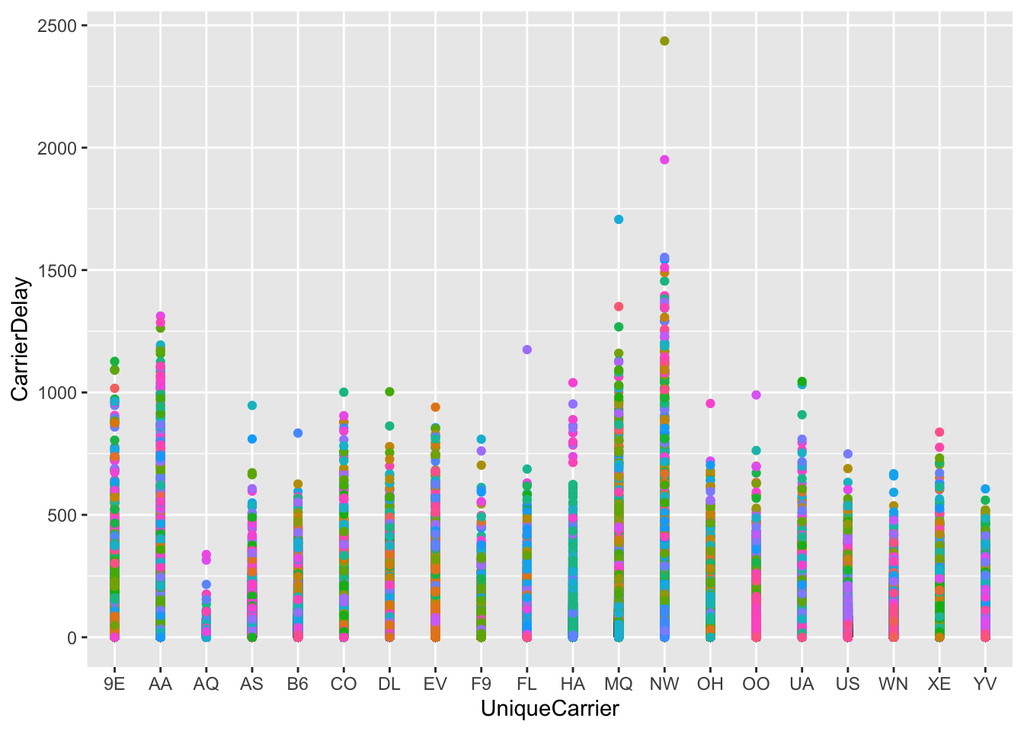

```r
ggplot(data = df, aes(x = UniqueCarrier, y = CarrierDelay)) +
  geom_point(aes(color = Origin), show.legend = FALSE, na.rm = TRUE)
```

# Summary Departure Delays

This simply summarizes the Departure Delays data showing the minimum departure delay for the entire year was 6 minutes. This is interesting as not a single flight departed on time showing some sort of inefficiency.  
CRSDepTime is the estimated departure time.

```r
selectedCol <- c(10, 7, 6, 17, 18)
summary(df[selectedCol])
```

```
##  UniqueCarrier      CRSDepTime      DepTime        DepDelay
##  WN     :377602   Min.   :   0   Min.   :   1   Min.   :   6.00
##  AA     :191865   1st Qu.:1135   1st Qu.:1203   1st Qu.:  12.00
##  MQ     :141920   Median :1510   Median :1545   Median :  24.00
##  UA     :141426   Mean   :1467   Mean   :1519   Mean   :  43.19
##  OO     :132433   3rd Qu.:1815   3rd Qu.:1900   3rd Qu.:  53.00
##  DL     :114238   Max.   :2359   Max.   :2400   Max.   :2467.00
##  (Other):837274
##      Origin
##  ATL    : 131613
##  ORD    : 125979
##  DFW    :  95414
##  DEN    :  74323
##  LAX    :  58772
##  IAH    :  56847
##  (Other):1393810
```

# Summary Arrival Delays

This data summarization is for the arrival delays. Looking closly something to notice is that the arrival delays has a minimum of -109 minutes. This is saying that in the best conditions with a very minimal departure delay the flight actually arrived 109 minutes early. This can be due to a tail wind or the pilots pushing to plane faster.

```r
selectedCol <- c(10, 8, 9, 16, 19)
summary(df[selectedCol])
```

```
##  UniqueCarrier       ArrTime       CRSArrTime      ArrDelay
##  WN     :377602   Min.   :   1   Min.   :   0   Min.   :-109.0
##  AA     :191865   1st Qu.:1316   1st Qu.:1325   1st Qu.:   9.0
##  MQ     :141920   Median :1715   Median :1705   Median :  24.0
##  UA     :141426   Mean   :1610   Mean   :1634   Mean   :  42.2
##  OO     :132433   3rd Qu.:2030   3rd Qu.:2014   3rd Qu.:  56.0
##  DL     :114238   Max.   :2400   Max.   :2400   Max.   :2461.0
##  (Other):837274   NA's   :7110                  NA's   :8387
##       Dest
##  ORD    : 108984
##  ATL    : 106898
##  DFW    :  70657
##  DEN    :  63003
##  LAX    :  59969
##  EWR    :  55861
##  (Other):1471386
```